# Hyperparameter Exploration: Learning Rate, Optimiser, and Batch Size

**DATA425 / STATS448 | Assignment 3 Q3**

This notebook trains fully connected networks on a challenging image classification dataset and systematically varies three hyperparameters to observe their effect on training dynamics:

1. **Learning rate** — too high, too small, and sensible
2. **Optimiser** — SGD, RMSProp, Adam
3. **Batch size** — mini-batch vs full-batch gradient descent

Each experiment keeps all other settings fixed and changes only the hyperparameter under study.

```python
import os
os.environ.setdefault("TF_CPP_MIN_LOG_LEVEL", "2")
os.environ.setdefault("TF_ENABLE_ONEDNN_OPTS", "0")

import warnings
warnings.filterwarnings("ignore")

import numpy as np
import matplotlib.pyplot as plt
import tensorflow as tf
from tensorflow import keras
from tensorflow.keras import layers
from sklearn.model_selection import train_test_split

SEED = 42
np.random.seed(SEED)
tf.keras.utils.set_random_seed(SEED)

plt.rcParams["figure.figsize"] = (9, 5)
plt.rcParams["font.size"]      = 12
plt.rcParams["axes.grid"]      = True
plt.rcParams["grid.alpha"]     = 0.25

print(f"TensorFlow {tf.__version__}")
```

```
TensorFlow 2.21.0
```

```
Dataset      : cifar10
Input shape  : (32, 32, 3)
Classes      : 10  ['airplane', 'automobile', 'bird', 'cat', 'deer', 'dog', 'frog', 'horse', 'ship', 'truck']
Train        : 42,500
Val          : 7,500
Test         : 10,000
```

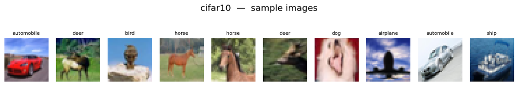

```python
# ── Dataset selection ────────────────────────────────────────────────────────
DATASET = "cifar10"       # "cifar10" | "fashion_mnist"
# ─────────────────────────────────────────────────────────────────────────────

def load_dataset(name, val_fraction=0.15, random_state=SEED):
    """
    Load and normalise one of two challenging datasets.

    cifar10       : 60,000 images, 32×32 RGB,       10 classes
    fashion_mnist : 70,000 images, 28×28 greyscale, 10 classes

    Returns
    -------
    dict with keys: X_train, y_train, X_val, y_val, X_test, y_test,
                    input_shape, num_classes
    """
    name = name.lower()
    if name == "cifar10":
        (X_tr, y_tr), (X_test, y_test) = keras.datasets.cifar10.load_data()
        class_names = ["airplane","automobile","bird","cat","deer",
                       "dog","frog","horse","ship","truck"]
    elif name == "fashion_mnist":
        (X_tr, y_tr), (X_test, y_test) = keras.datasets.fashion_mnist.load_data()
        class_names = ["T-shirt","Trouser","Pullover","Dress","Coat",
                       "Sandal","Shirt","Sneaker","Bag","Ankle boot"]
    else:
        raise ValueError(f"Unknown dataset '{name}'. Choose: cifar10 | fashion_mnist")

    X_tr   = X_tr.astype("float32")   / 255.0
    X_test = X_test.astype("float32") / 255.0
    y_tr   = y_tr.astype("int64").ravel()
    y_test = y_test.astype("int64").ravel()

    X_train, X_val, y_train, y_val = train_test_split(
        X_tr, y_tr, test_size=val_fraction,
        random_state=random_state, stratify=y_tr
    )

    input_shape = X_train.shape[1:]
    num_classes = int(np.unique(y_tr).size)

    print(f"Dataset      : {name}")
    print(f"Input shape  : {input_shape}")
    print(f"Classes      : {num_classes}  {class_names}")
    print(f"Train        : {X_train.shape[0]:,}")
    print(f"Val          : {X_val.shape[0]:,}")
    print(f"Test         : {X_test.shape[0]:,}")

    return dict(X_train=X_train, y_train=y_train,
                X_val=X_val,     y_val=y_val,
                X_test=X_test,   y_test=y_test,
                input_shape=input_shape, num_classes=num_classes,
                class_names=class_names)


ds = load_dataset(DATASET)

X_train, y_train = ds["X_train"], ds["y_train"]
X_val,   y_val   = ds["X_val"],   ds["y_val"]
X_test,  y_test  = ds["X_test"],  ds["y_test"]
INPUT_SHAPE      = ds["input_shape"]
NUM_CLASSES      = ds["num_classes"]
CLASS_NAMES      = ds["class_names"]

# ── sample grid ──────────────────────────────────────────────────────────────
n_show = 10
fig, axes = plt.subplots(1, n_show, figsize=(12, 2))
for ax, img, lbl in zip(axes, X_train[:n_show], y_train[:n_show]):
    ax.imshow(img, cmap="gray" if img.ndim == 2 else None)
    ax.set_title(CLASS_NAMES[lbl], fontsize=8)
    ax.axis("off")
plt.suptitle(f"{DATASET}  —  sample images", y=1.05)
plt.tight_layout()
plt.show()
```

## 1. Learning Rate

The learning rate $\eta$ controls how large each gradient descent step is:

$$w \leftarrow w - \eta \cdot \nabla L(w)$$

Three qualitatively different regimes exist regardless of the dataset or network:

| Regime | What happens |
| --- | --- |
| **Too small** | Loss decreases but very slowly — the network is barely learning each epoch |
| **Sensible** | Loss drops steadily and smoothly — the network converges efficiently |
| **Too large** | Loss bounces around or diverges — the optimiser overshoots the minimum every step |

The experiment below trains the same network architecture three times with plain SGD, changing only the learning rate. Everything else — architecture, epochs, batch size, random seed — is held constant.

```python
import json, pathlib

# ── Learning rate values — edit these to experiment ──────────────────────────
LR_TOO_SMALL = 0.0005   # barely moves        — very slow convergence
LR_SENSIBLE  = 0.01     # steady descent      — efficient learning
LR_TOO_LARGE = 0.15     # overshoots/diverges — bounces or flatlines
# ─────────────────────────────────────────────────────────────────────────────

EPOCHS     = 30
BATCH_SIZE = 128

LR_CONFIGS = {
    f"too small  (lr = {LR_TOO_SMALL})": LR_TOO_SMALL,
    f"sensible   (lr = {LR_SENSIBLE})":  LR_SENSIBLE,
    f"too large  (lr = {LR_TOO_LARGE})": LR_TOO_LARGE,
}

def _lr_str(v): return str(v).replace(".", "p")
def _safe(label):
    return label.replace(" ", "_").replace("=", "").replace(".", "p").replace("(","").replace(")","")

SAVE_DIR = pathlib.Path(
    f"saved/lr_experiment/s{_lr_str(LR_TOO_SMALL)}_m{_lr_str(LR_SENSIBLE)}_l{_lr_str(LR_TOO_LARGE)}"
)

# ── callback: evaluates on test set at the end of every epoch ─────────────────
class TestAccHistory(keras.callbacks.Callback):
    def __init__(self, X_test, y_test):
        super().__init__()
        self.X_test   = X_test
        self.y_test   = y_test
        self.test_accs = []

    def on_epoch_end(self, epoch, logs=None):
        _, acc = self.model.evaluate(self.X_test, self.y_test, verbose=0)
        self.test_accs.append(float(acc))

# ── cache check — also invalidates if per-epoch test data is missing ──────────
_results_file = SAVE_DIR / "lr_results.json"
_model_files  = [SAVE_DIR / f"model_{_safe(l)}.keras" for l in LR_CONFIGS]

def _cache_valid():
    if not (_results_file.exists() and all(p.exists() for p in _model_files)):
        return False
    with open(_results_file) as f:
        data = json.load(f)
    # invalidate if any entry is missing per-epoch test accuracy
    return all("test_acc_per_epoch" in v for v in data.values())

if _cache_valid():
    print(f"Saved results found — loading from  {SAVE_DIR}\n")
    with open(_results_file) as f:
        lr_results = json.load(f)
    lr_models = {l: keras.models.load_model(SAVE_DIR / f"model_{_safe(l)}.keras")
                 for l in lr_results}
    EPOCHS = len(lr_results[next(iter(lr_results))]["loss"])
    for label, hist in lr_results.items():
        print(f"  {label:<32}  test_acc = {hist['test_accuracy']:.3f}")

else:
    print("No saved results (or missing per-epoch test data) — training from scratch.\n")

    def build_model(learning_rate):
        tf.keras.utils.set_random_seed(SEED)
        model = keras.Sequential([
            keras.Input(shape=INPUT_SHAPE),
            layers.Flatten(),
            layers.Dense(256, activation="relu"),
            layers.Dense(128, activation="relu"),
            layers.Dense(NUM_CLASSES, activation="softmax"),
        ], name=f"lr_{_lr_str(learning_rate)}")
        model.compile(
            optimizer=keras.optimizers.SGD(learning_rate=learning_rate),
            loss="sparse_categorical_crossentropy",
            metrics=["accuracy"],
        )
        return model

    lr_results, lr_models = {}, {}
    for label, lr in LR_CONFIGS.items():
        print(f"Training: {label} ...", end=" ", flush=True)
        cb    = TestAccHistory(X_test, y_test)
        model = build_model(lr)
        hist  = model.fit(X_train, y_train,
                          validation_data=(X_val, y_val),
                          epochs=EPOCHS, batch_size=BATCH_SIZE,
                          callbacks=[cb], verbose=0)
        _, test_acc = model.evaluate(X_test, y_test, verbose=0)
        lr_results[label] = hist.history
        lr_results[label]["test_accuracy"]     = test_acc
        lr_results[label]["test_acc_per_epoch"] = cb.test_accs
        lr_models[label] = model
        print(f"done  (val_acc = {hist.history['val_accuracy'][-1]:.3f}  |  test_acc = {test_acc:.3f})")

    SAVE_DIR.mkdir(parents=True, exist_ok=True)
    with open(_results_file, "w") as f:
        json.dump(lr_results, f)
    for label, model in lr_models.items():
        model.save(SAVE_DIR / f"model_{_safe(label)}.keras")
    print(f"\nSaved to  {SAVE_DIR.resolve()}")
```

```
Saved results found — loading from  saved\lr_experiment\s0p0005_m0p01_l0p15

  too small  (lr = 0.0005)          test_acc = 0.357
  sensible   (lr = 0.01)            test_acc = 0.419
  too large  (lr = 0.15)            test_acc = 0.433
```

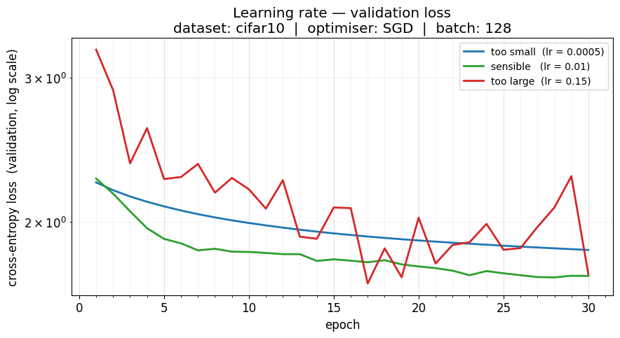

```python
# ── Graph 1: Validation loss per epoch ───────────────────────────────────────

_colours = ["#1f77b4", "#2ca02c", "#d62728"]   # blue / green / red
colours  = {label: col for label, col in zip(LR_CONFIGS.keys(), _colours)}
epochs_x = range(1, EPOCHS + 1)

from matplotlib.ticker import MultipleLocator

fig, ax = plt.subplots()
for label, hist in lr_results.items():
    ax.plot(epochs_x, hist["val_loss"],
            color=colours[label], linewidth=2, label=label)

ax.set_yscale("log")
ax.set_xlabel("epoch")
ax.set_ylabel("cross-entropy loss  (validation, log scale)")
ax.set_title(f"Learning rate — validation loss\n"
             f"dataset: {DATASET}  |  optimiser: SGD  |  batch: {BATCH_SIZE}")
ax.legend(fontsize=10)

ax.xaxis.set_major_locator(MultipleLocator(5))   # labelled tick every 5 epochs
ax.xaxis.set_minor_locator(MultipleLocator(1))   # unlabelled tick every epoch
ax.grid(which="major", alpha=0.35)
ax.grid(which="minor", alpha=0.15)               # faint vertical line each epoch

plt.tight_layout()
plt.show()
```

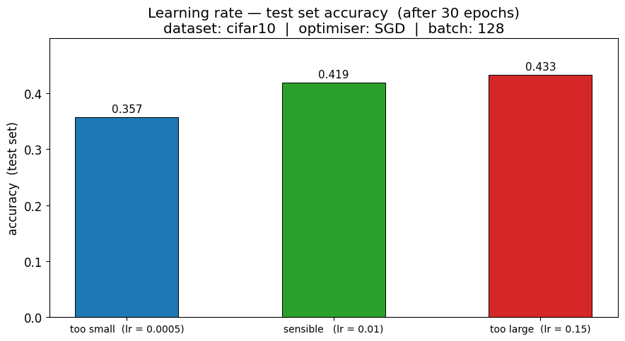

```python
# ── Graph 2: Test set accuracy per configuration ─────────────────────────────

labels    = list(lr_results.keys())
test_accs = [lr_results[l]["test_accuracy"] for l in labels]
bar_cols  = [colours[l] for l in labels]

fig, ax = plt.subplots()
bars = ax.bar(labels, test_accs, color=bar_cols, width=0.5, edgecolor="black", linewidth=0.7)

# value labels on top of each bar
for bar, val in zip(bars, test_accs):
    ax.text(bar.get_x() + bar.get_width() / 2, bar.get_height() + 0.005,
            f"{val:.3f}", ha="center", va="bottom", fontsize=11)

ax.set_ylim(0, max(test_accs) * 1.15)
ax.set_ylabel("accuracy  (test set)")
ax.set_title(f"Learning rate — test set accuracy  (after {EPOCHS} epochs)\n"
             f"dataset: {DATASET}  |  optimiser: SGD  |  batch: {BATCH_SIZE}")
ax.tick_params(axis="x", labelsize=10)
ax.grid(False)
plt.tight_layout()
plt.show()
```

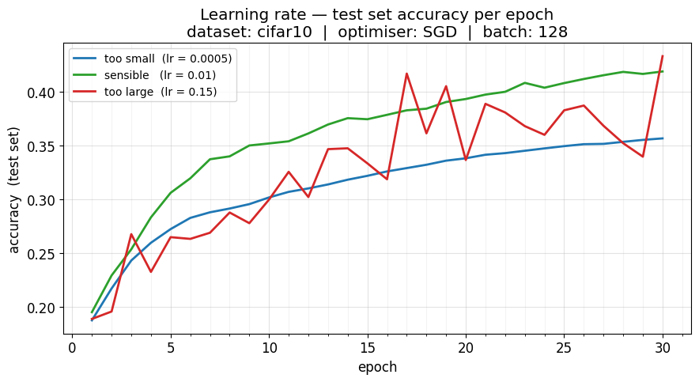

```python
# ── Graph 3: Test set accuracy per epoch ─────────────────────────────────────

from matplotlib.ticker import MultipleLocator

fig, ax = plt.subplots()
for label, hist in lr_results.items():
    ax.plot(epochs_x, hist["test_acc_per_epoch"],
            color=colours[label], linewidth=2, label=label)

ax.set_xlabel("epoch")
ax.set_ylabel("accuracy  (test set)")
ax.set_title(f"Learning rate — test set accuracy per epoch\n"
             f"dataset: {DATASET}  |  optimiser: SGD  |  batch: {BATCH_SIZE}")
ax.legend(fontsize=10)

ax.xaxis.set_major_locator(MultipleLocator(5))   # labelled tick every 5 epochs
ax.xaxis.set_minor_locator(MultipleLocator(1))   # unlabelled tick every epoch
ax.grid(which="major", alpha=0.35)
ax.grid(which="minor", alpha=0.15)               # faint vertical line each epoch

plt.tight_layout()
plt.show()
```

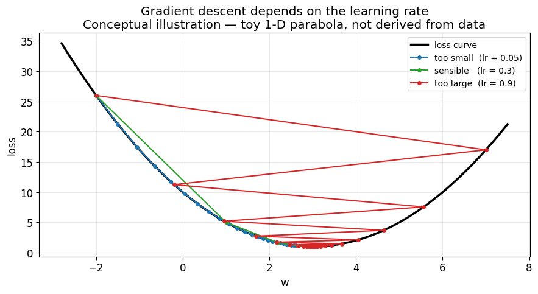

```python
# ── Graph 4: Loss surface — gradient descent paths (toy 1-D parabola) ─────────
#
# Purely illustrative — not derived from the dataset.
# A toy parabola L(w) = (w - W_OPT)^2 + L_MIN is used so the loss surface
# can be drawn in 2-D.  The three learning rates below are chosen to clearly
# show the three visual regimes; they are NOT the network training LRs above.

W_OPT = 3.0          # minimum of the parabola
L_MIN = 1.0          # loss at the minimum
W_INIT = -2.0        # shared starting point for all three paths
STEPS = 25           # gradient descent steps to trace

TOY_LR_SMALL    = 0.05    # slow — many tiny steps
TOY_LR_SENSIBLE = 0.30    # steady — converges in ~5 steps
TOY_LR_LARGE    = 0.90    # overshoots — bounces across the minimum

def _toy_loss(w): return (w - W_OPT) ** 2 + L_MIN
def _toy_grad(w): return 2.0 * (w - W_OPT)

toy_configs = {
    f"too small  (lr = {TOY_LR_SMALL})":    (TOY_LR_SMALL,    "#1f77b4"),
    f"sensible   (lr = {TOY_LR_SENSIBLE})": (TOY_LR_SENSIBLE, "#2ca02c"),
    f"too large  (lr = {TOY_LR_LARGE})":    (TOY_LR_LARGE,    "#d62728"),
}

w_range = np.linspace(-2.8, 7.5, 400)

fig, ax = plt.subplots()
ax.plot(w_range, _toy_loss(w_range), color="black", linewidth=2.5, label="loss curve")

for label, (lr, col) in toy_configs.items():
    w = W_INIT
    ws = [w]
    for _ in range(STEPS):
        w = w - lr * _toy_grad(w)
        ws.append(w)
    ws = np.array(ws)
    ax.plot(ws, _toy_loss(ws), color=col, linewidth=1.5,
            marker="o", markersize=4, label=label)

ax.set_xlabel("w")
ax.set_ylabel("loss")
ax.set_title("Gradient descent depends on the learning rate\n"
             "Conceptual illustration — toy 1-D parabola, not derived from data")
ax.legend(fontsize=10)
plt.tight_layout()
plt.show()
```

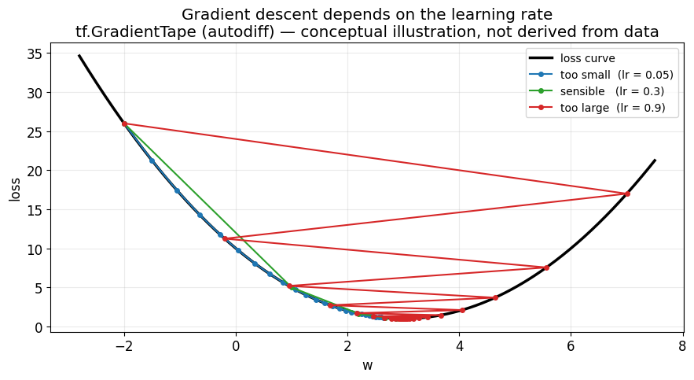

```python
# ── Graph 4b: Same paths via tf.GradientTape (automatic differentiation) ──────
#
# Identical setup to Graph 4 — same toy parabola, same W_INIT, same toy LRs.
# Gradients are now computed by TF autodiff rather than the analytic formula.
# Paths should be numerically identical, confirming autodiff == hand-calc.
# Also purely illustrative — not derived from the dataset.

_W_OPT_tf = tf.constant(W_OPT, dtype=tf.float32)
_L_MIN_tf  = tf.constant(L_MIN, dtype=tf.float32)

def _toy_loss_tf(w_var):
    return (w_var - _W_OPT_tf) ** 2 + _L_MIN_tf

def _run_gd_tf(w_init, lr, steps=STEPS):
    w   = tf.Variable(float(w_init), dtype=tf.float32)
    opt = keras.optimizers.SGD(learning_rate=lr)
    ws  = [float(w.numpy())]
    for _ in range(steps):
        with tf.GradientTape() as tape:
            loss = _toy_loss_tf(w)
        grads = tape.gradient(loss, [w])
        opt.apply_gradients(zip(grads, [w]))
        ws.append(float(w.numpy()))
    return np.array(ws)

fig, ax = plt.subplots()
ax.plot(w_range, _toy_loss(w_range), color="black", linewidth=2.5, label="loss curve")

for label, (lr, col) in toy_configs.items():
    ws = _run_gd_tf(W_INIT, lr)
    ax.plot(ws, _toy_loss(ws), color=col, linewidth=1.5,
            marker="o", markersize=4, label=label)

ax.set_xlabel("w")
ax.set_ylabel("loss")
ax.set_title("Gradient descent depends on the learning rate\n"
             "tf.GradientTape (autodiff) — conceptual illustration, not derived from data")
ax.legend(fontsize=10)
plt.tight_layout()
plt.show()
```

## 2. Optimiser

The optimiser decides *how* gradient information is used to update weights each step.

| Optimiser | Key idea |
| --- | --- |
| **SGD** | Raw gradient scaled by a single learning rate — simple but can be slow or sensitive to the LR choice |
| **RMSProp** | Divides each update by a running average of recent squared gradients — adapts the step size per parameter |
| **Adam** | Combines RMSProp's per-parameter scaling with momentum — usually the most reliable default |

Everything below is held fixed: same architecture, same dataset, same batch size, same number of epochs. Only the optimiser changes.

```python
from sklearn.metrics import confusion_matrix

# ── Optimiser hyperparameters — edit these to experiment ─────────────────────
OPT_LR_SGD     = 0.01     # SGD learning rate  (same as LR_SENSIBLE above)
OPT_LR_RMSPROP = 0.001    # RMSProp learning rate  (standard default)
OPT_LR_ADAM    = 0.001    # Adam learning rate     (standard default)
OPT_MOMENTUM   = 0.9      # momentum for SGD only
OPT_EPOCHS     = 30
OPT_BATCH_SIZE = 128
# ─────────────────────────────────────────────────────────────────────────────

_OPT_NAMES   = ["SGD", "RMSProp", "Adam"]
_OPT_COLOURS = {"SGD": "#1f77b4", "RMSProp": "#ff7f0e", "Adam": "#2ca02c"}
_OPT_DISPLAY = {
    "SGD":     f"SGD      (lr={OPT_LR_SGD}, momentum={OPT_MOMENTUM})",
    "RMSProp": f"RMSProp  (lr={OPT_LR_RMSPROP})",
    "Adam":    f"Adam     (lr={OPT_LR_ADAM})",
}

def _make_opt(name):
    if name == "SGD":
        return keras.optimizers.SGD(learning_rate=OPT_LR_SGD, momentum=OPT_MOMENTUM)
    if name == "RMSProp":
        return keras.optimizers.RMSprop(learning_rate=OPT_LR_RMSPROP)
    return keras.optimizers.Adam(learning_rate=OPT_LR_ADAM)

OPT_SAVE_DIR = pathlib.Path(
    f"saved/opt_experiment/"
    f"sgd{_lr_str(OPT_LR_SGD)}_rms{_lr_str(OPT_LR_RMSPROP)}_adam{_lr_str(OPT_LR_ADAM)}"
)

_opt_results_file = OPT_SAVE_DIR / "opt_results.json"
_opt_model_files  = [OPT_SAVE_DIR / f"model_{n}.keras" for n in _OPT_NAMES]

def _opt_cache_valid():
    if not (_opt_results_file.exists() and all(p.exists() for p in _opt_model_files)):
        return False
    with open(_opt_results_file) as f:
        data = json.load(f)
    return all("test_acc_per_epoch" in v and "test_predictions" in v for v in data.values())

if _opt_cache_valid():
    print(f"Saved results found — loading from  {OPT_SAVE_DIR}\n")
    with open(_opt_results_file) as f:
        opt_results = json.load(f)
    opt_models = {n: keras.models.load_model(OPT_SAVE_DIR / f"model_{n}.keras")
                  for n in _OPT_NAMES}
    OPT_EPOCHS = len(opt_results[next(iter(opt_results))]["val_accuracy"])
    for name, hist in opt_results.items():
        print(f"  {name:<10}  test_acc = {hist['test_accuracy']:.3f}")

else:
    print("No saved results — training from scratch.\n")

    def _build_opt_model():
        tf.keras.utils.set_random_seed(SEED)
        m = keras.Sequential([
            keras.Input(shape=INPUT_SHAPE),
            layers.Flatten(),
            layers.Dense(256, activation="relu"),
            layers.Dense(128, activation="relu"),
            layers.Dense(NUM_CLASSES, activation="softmax"),
        ])
        return m

    opt_results, opt_models = {}, {}
    for name in _OPT_NAMES:
        print(f"Training: {name} ...", end=" ", flush=True)
        cb    = TestAccHistory(X_test, y_test)
        model = _build_opt_model()
        model.compile(optimizer=_make_opt(name),
                      loss="sparse_categorical_crossentropy",
                      metrics=["accuracy"])
        hist = model.fit(X_train, y_train,
                         validation_data=(X_val, y_val),
                         epochs=OPT_EPOCHS, batch_size=OPT_BATCH_SIZE,
                         callbacks=[cb], verbose=0)
        _, test_acc = model.evaluate(X_test, y_test, verbose=0)
        y_pred = np.argmax(model.predict(X_test, verbose=0), axis=1).tolist()
        opt_results[name] = hist.history
        opt_results[name]["test_accuracy"]      = test_acc
        opt_results[name]["test_acc_per_epoch"] = cb.test_accs
        opt_results[name]["test_predictions"]   = y_pred
        opt_models[name] = model
        print(f"done  (val_acc = {hist.history['val_accuracy'][-1]:.3f}  |  test_acc = {test_acc:.3f})")

    OPT_SAVE_DIR.mkdir(parents=True, exist_ok=True)
    with open(_opt_results_file, "w") as f:
        json.dump(opt_results, f)
    for name, model in opt_models.items():
        model.save(OPT_SAVE_DIR / f"model_{name}.keras")
    print(f"\nSaved to  {OPT_SAVE_DIR.resolve()}")
```

```
Saved results found — loading from  saved\opt_experiment\sgd0p01_rms0p001_adam0p001

  SGD         test_acc = 0.477
  RMSProp     test_acc = 0.373
  Adam        test_acc = 0.473
```

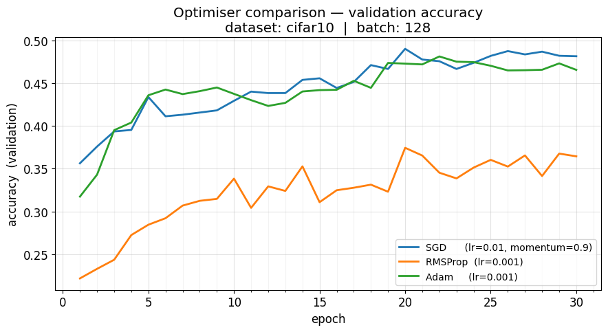

```python
# ── Graph 1: Validation accuracy per epoch ───────────────────────────────────

from matplotlib.ticker import MultipleLocator

opt_epochs_x = range(1, OPT_EPOCHS + 1)

fig, ax = plt.subplots()
for name, hist in opt_results.items():
    ax.plot(opt_epochs_x, hist["val_accuracy"],
            color=_OPT_COLOURS[name], linewidth=2, label=_OPT_DISPLAY[name])

ax.set_xlabel("epoch")
ax.set_ylabel("accuracy  (validation)")
ax.set_title(f"Optimiser comparison — validation accuracy\n"
             f"dataset: {DATASET}  |  batch: {OPT_BATCH_SIZE}")
ax.legend(fontsize=10)
ax.xaxis.set_major_locator(MultipleLocator(5))
ax.xaxis.set_minor_locator(MultipleLocator(1))
ax.grid(which="major", alpha=0.35)
ax.grid(which="minor", alpha=0.15)
plt.tight_layout()
plt.show()
```

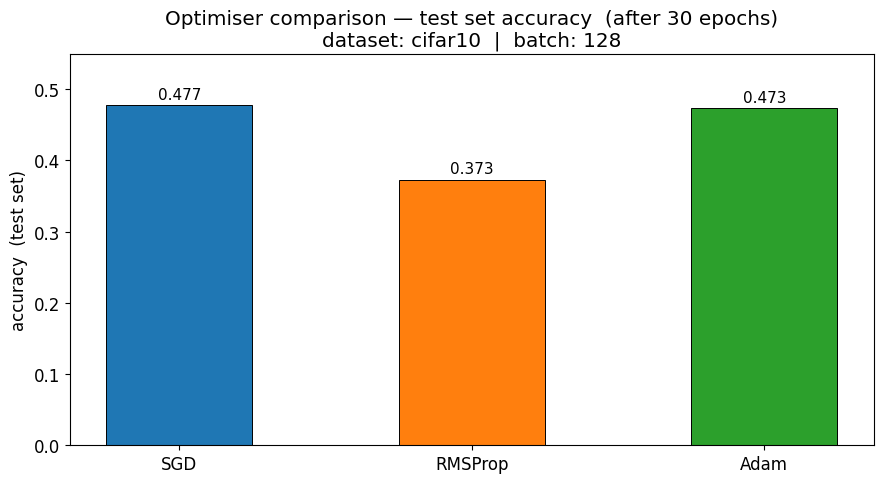

```python
# ── Graph 2: Final test accuracy bar chart ────────────────────────────────────

opt_test_accs = [opt_results[n]["test_accuracy"] for n in _OPT_NAMES]
opt_bar_cols  = [_OPT_COLOURS[n] for n in _OPT_NAMES]

fig, ax = plt.subplots()
bars = ax.bar(_OPT_NAMES, opt_test_accs, color=opt_bar_cols,
              width=0.5, edgecolor="black", linewidth=0.7)
for bar, val in zip(bars, opt_test_accs):
    ax.text(bar.get_x() + bar.get_width() / 2, bar.get_height() + 0.005,
            f"{val:.3f}", ha="center", va="bottom", fontsize=11)

ax.set_ylim(0, max(opt_test_accs) * 1.15)
ax.set_ylabel("accuracy  (test set)")
ax.set_title(f"Optimiser comparison — test set accuracy  (after {OPT_EPOCHS} epochs)\n"
             f"dataset: {DATASET}  |  batch: {OPT_BATCH_SIZE}")
ax.grid(False)
plt.tight_layout()
plt.show()
```

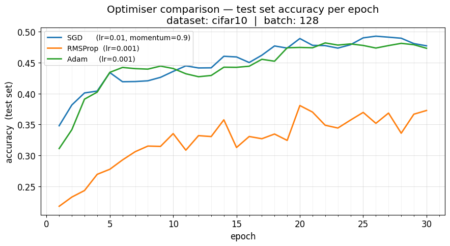

```python
# ── Graph 3: Test set accuracy per epoch ─────────────────────────────────────

fig, ax = plt.subplots()
for name, hist in opt_results.items():
    ax.plot(opt_epochs_x, hist["test_acc_per_epoch"],
            color=_OPT_COLOURS[name], linewidth=2, label=_OPT_DISPLAY[name])

ax.set_xlabel("epoch")
ax.set_ylabel("accuracy  (test set)")
ax.set_title(f"Optimiser comparison — test set accuracy per epoch\n"
             f"dataset: {DATASET}  |  batch: {OPT_BATCH_SIZE}")
ax.legend(fontsize=10)
ax.xaxis.set_major_locator(MultipleLocator(5))
ax.xaxis.set_minor_locator(MultipleLocator(1))
ax.grid(which="major", alpha=0.35)
ax.grid(which="minor", alpha=0.15)
plt.tight_layout()
plt.show()
```

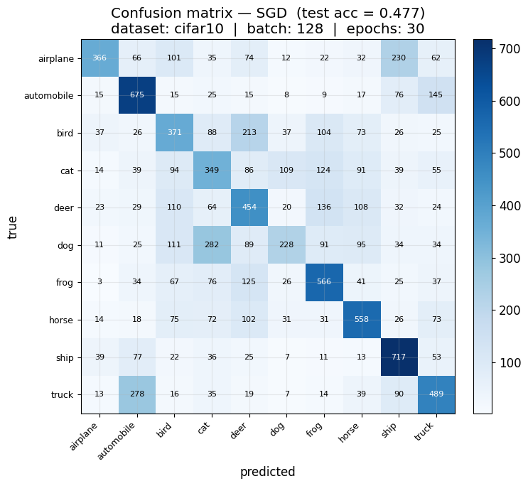

```python
# ── Graph 4a: Confusion matrix — SGD ─────────────────────────────────────────

def _plot_confusion_matrix(name):
    y_pred = np.array(opt_results[name]["test_predictions"])
    cm     = confusion_matrix(y_test, y_pred)
    thresh = cm.max() / 2

    fig, ax = plt.subplots(figsize=(8, 7))
    im = ax.imshow(cm, cmap="Blues")
    ax.set_xticks(range(NUM_CLASSES))
    ax.set_yticks(range(NUM_CLASSES))
    ax.set_xticklabels(CLASS_NAMES, rotation=45, ha="right", fontsize=9)
    ax.set_yticklabels(CLASS_NAMES, fontsize=9)
    ax.set_xlabel("predicted")
    ax.set_ylabel("true")
    ax.set_title(f"Confusion matrix — {name}  (test acc = {opt_results[name]['test_accuracy']:.3f})\n"
                 f"dataset: {DATASET}  |  batch: {OPT_BATCH_SIZE}  |  epochs: {OPT_EPOCHS}")
    for i in range(NUM_CLASSES):
        for j in range(NUM_CLASSES):
            ax.text(j, i, str(cm[i, j]),
                    ha="center", va="center", fontsize=8,
                    color="white" if cm[i, j] > thresh else "black")
    fig.colorbar(im, fraction=0.046, pad=0.04)
    plt.tight_layout()
    plt.show()

_plot_confusion_matrix("SGD")
```

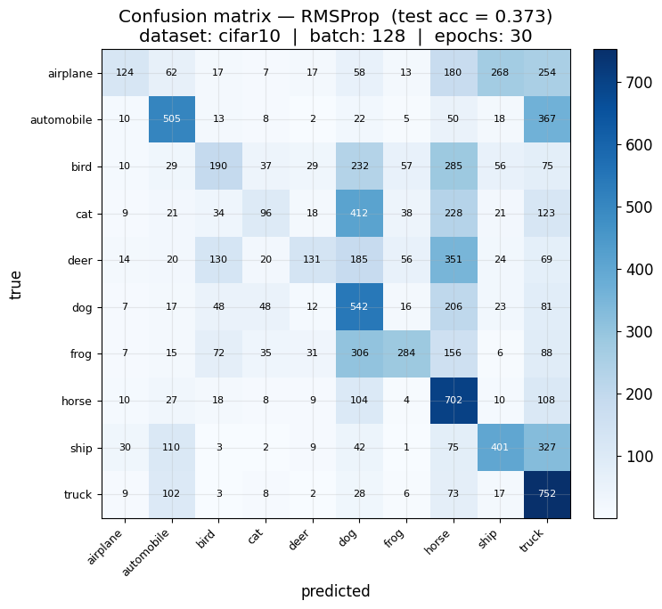

```python
# ── Graph 4b: Confusion matrix — RMSProp ─────────────────────────────────────

_plot_confusion_matrix("RMSProp")
```

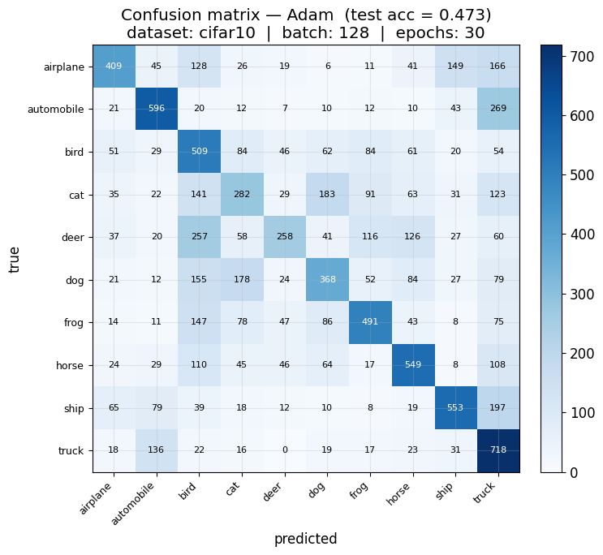

```python
# ── Graph 4c: Confusion matrix — Adam ────────────────────────────────────────

_plot_confusion_matrix("Adam")
```

**Observations:**

The confusion matrices show *which classes* each optimiser struggles with most — look for rows with mass spread across multiple columns (true class being misclassified everywhere).

Do not treat these rankings as universal. Changing the learning rate, architecture, or dataset can reverse the order.

## 3. Batch Size

Each gradient update step can use a different amount of data:

| Variant | Batch size | Gradient quality | Loss curve |
| --- | --- | --- | --- |
| **Stochastic GD** | 1 sample | Very noisy — 1 sample per step | Extremely jagged |
| **Mini-Batch GD** | small subset | Noisy but directional | Jagged but trending down |
| **Full-Batch GD** | all data | Exact — no sampling noise | Perfectly smooth |

The x-axis is **iterations** (gradient update steps), not epochs — this makes all three directly comparable since each method takes exactly the same number of steps.

A subset of the training data is used so full-batch GD remains fast. The custom `tf.GradientTape` loop gives precise control over the x-axis.

```python
# ── Batch size hyperparameters — edit these to experiment ─────────────────────
N_BATCH_SAMPLES = 5000    # training subset — keeps full-batch fast
N_ITERS         = 300     # gradient update steps (same for all three methods)
BATCH_LR        = 0.01    # fixed LR — same optimiser (SGD), only batch size changes

BS_STOCHASTIC = 1
BS_MINIBATCH  = 128
BS_FULLBATCH  = N_BATCH_SAMPLES   # all available samples = true full-batch
# ─────────────────────────────────────────────────────────────────────────────

BATCH_CONFIGS = {
    f"Stochastic GD  (bs=1)":                (BS_STOCHASTIC, "#d62728"),
    f"Mini-Batch GD  (bs={BS_MINIBATCH})":   (BS_MINIBATCH,  "#2ca02c"),
    f"Full-Batch GD  (bs={BS_FULLBATCH})":   (BS_FULLBATCH,  "#1f77b4"),
}

BATCH_SAVE_DIR = pathlib.Path(
    f"saved/batch_experiment/"
    f"iters{N_ITERS}_lr{_lr_str(BATCH_LR)}_N{N_BATCH_SAMPLES}"
)
_batch_results_file = BATCH_SAVE_DIR / "batch_results.json"

def _batch_cache_valid():
    if not _batch_results_file.exists():
        return False
    with open(_batch_results_file) as f:
        data = json.load(f)
    return len(data) == len(BATCH_CONFIGS) and all(
        len(v) == N_ITERS for v in data.values()
    )

if _batch_cache_valid():
    print(f"Saved results found — loading from  {BATCH_SAVE_DIR}\n")
    with open(_batch_results_file) as f:
        batch_results = json.load(f)
    for label, losses in batch_results.items():
        print(f"  {label:<42}  final_loss = {losses[-1]:.4f}")

else:
    print("No saved results — running gradient descent loops.\n")

    # fixed subset so full-batch stays fast and all methods see the same data
    _rng_sub = np.random.default_rng(SEED)
    _sub_idx = _rng_sub.choice(len(X_train), size=N_BATCH_SAMPLES, replace=False)
    X_sub    = X_train[_sub_idx].reshape(N_BATCH_SAMPLES, -1).astype("float32")
    y_sub    = y_train[_sub_idx].astype("int64")
    X_sub_tf = tf.constant(X_sub)
    y_sub_tf = tf.constant(y_sub)

    def _run_batch_gd(batch_size, n_iters, lr, seed=SEED):
        tf.keras.utils.set_random_seed(seed)
        _rng = np.random.default_rng(seed)
        N    = len(X_sub)

        model = keras.Sequential([
            keras.Input(shape=(X_sub.shape[1],)),
            layers.Dense(256, activation="relu"),
            layers.Dense(128, activation="relu"),
            layers.Dense(NUM_CLASSES, activation="softmax"),
        ])
        opt     = keras.optimizers.SGD(learning_rate=lr)
        loss_fn = keras.losses.SparseCategoricalCrossentropy()

        losses = []
        for _ in range(n_iters):
            # full-batch: use every sample; otherwise sample randomly
            idx     = np.arange(N) if batch_size >= N else _rng.integers(0, N, size=batch_size)
            X_batch = tf.gather(X_sub_tf, idx)
            y_batch = tf.gather(y_sub_tf, idx)
            with tf.GradientTape() as tape:
                loss = loss_fn(y_batch, model(X_batch, training=True))
            grads = tape.gradient(loss, model.trainable_variables)
            opt.apply_gradients(zip(grads, model.trainable_variables))
            losses.append(float(loss.numpy()))
        return losses

    batch_results = {}
    for label, (bs, _) in BATCH_CONFIGS.items():
        print(f"Running: {label} ...", end=" ", flush=True)
        losses = _run_batch_gd(bs, N_ITERS, BATCH_LR)
        batch_results[label] = losses
        print(f"done  (final loss = {losses[-1]:.4f})")

    BATCH_SAVE_DIR.mkdir(parents=True, exist_ok=True)
    with open(_batch_results_file, "w") as f:
        json.dump(batch_results, f)
    print(f"\nSaved to  {BATCH_SAVE_DIR.resolve()}")
```

```
Saved results found — loading from  saved\batch_experiment\iters300_lr0p01_N5000

  Stochastic GD  (bs=1)                       final_loss = 1.9738
  Mini-Batch GD  (bs=128)                     final_loss = 1.8461
  Full-Batch GD  (bs=5000)                    final_loss = 1.8542
```

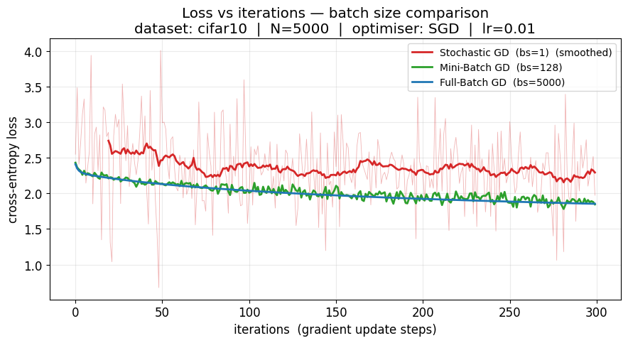

```python
# ── Graph: Loss vs iterations ─────────────────────────────────────────────────

iters_x = range(N_ITERS)

fig, ax = plt.subplots()
for label, (_, col) in BATCH_CONFIGS.items():
    losses = batch_results[label]
    # stochastic is very noisy — plot faint raw + bold rolling average
    if "Stochastic" in label:
        ax.plot(iters_x, losses, color=col, linewidth=0.6, alpha=0.35)
        window  = 20
        smooth  = np.convolve(losses, np.ones(window) / window, mode="valid")
        ax.plot(range(window - 1, N_ITERS), smooth,
                color=col, linewidth=2, label=label + "  (smoothed)")
    else:
        ax.plot(iters_x, losses, color=col, linewidth=2, label=label)

ax.set_xlabel("iterations  (gradient update steps)")
ax.set_ylabel("cross-entropy loss")
ax.set_title(f"Loss vs iterations — batch size comparison\n"
             f"dataset: {DATASET}  |  N={N_BATCH_SAMPLES}  |  optimiser: SGD  |  lr={BATCH_LR}")
ax.legend(fontsize=10)
plt.tight_layout()
plt.show()
```

**Observations:**

- **Stochastic GD (bs=1):** Each step uses a single random sample — the loss jumps wildly because one sample is an extremely noisy estimate of the true gradient. The faint raw curve and bold smoothed average are both shown in red.
  - *Advantages:* extremely fast per-step updates; computationally cheap; the noise can actually help **escape local minima** that full-batch GD would get stuck in.
  - *Disadvantages:* VERY noisy; unstable; oscillatory — the parameter path wanders erratically and convergence is hard to guarantee.
- **Mini-Batch GD (bs=128):** Averaging over 128 samples per step gives a much more reliable gradient direction — the curve trends downward with moderate noise. This is the practical default in deep learning: it keeps most of stochastic GD's speed while dramatically reducing the instability.
- **Full-Batch GD (bs=5000):** Every step uses all available data — the gradient is exact and the loss decreases smoothly and monotonically. No noise, no oscillation, but each step is expensive and it cannot escape local minima once it falls in.

**The noise is NOT always bad.**

The stochasticity can:

- help escape local minima,
- help escape saddle points,
- improve exploration of parameter space.

This is actually one reason why SGD-based methods work so well in deep learning.

The key trade-off is **noise vs. cost per step**: stochastic steps are cheapest but noisiest; full-batch steps are most accurate but expensive. Mini-batch sits in the middle and is why `batch_size=32–256` is the standard choice in practice.